# stchlk_exome_annotation.Rmd

Kevin Stachelek

1/30/2018

load rb datasets. Keep in mind that only samples c(“24-T”, “28-C”, “28-T”, “29-T”, “29-C”, “31-T”, “31-C”, “41-C”, “46-T”, “46-C”, “48-T”, “48-C”) have ready rb variants detected

# load mutect2 vcf files

# generate lists of vcfs for each type of data: cobrinik cell line, cobrinik tumor, cobrinik normal, and reynolds cell line

## load strelka snv vcf files

## load strelka indel vcf files

# tidy mutect2 variants

# define collate_vcfs

# collate mutect2 vcfs

# collate strelka snvs

# collate strelka indels

# read in raw strelka snvs

# read in raw strelka indels

# retidy strelka snvs

# retidy strelka indels

# read in clean strelka variants and combine

# read in combined strelka variants

# load unfiltered mutect2 variants

# retidy mutect2 variants

# load clean mutect2 variants

# create table of mutect2 somatic variants

# collate RB1 mutect2 snvs for all samples

# find variants that are shared between mutect2 tumor and matched cell line

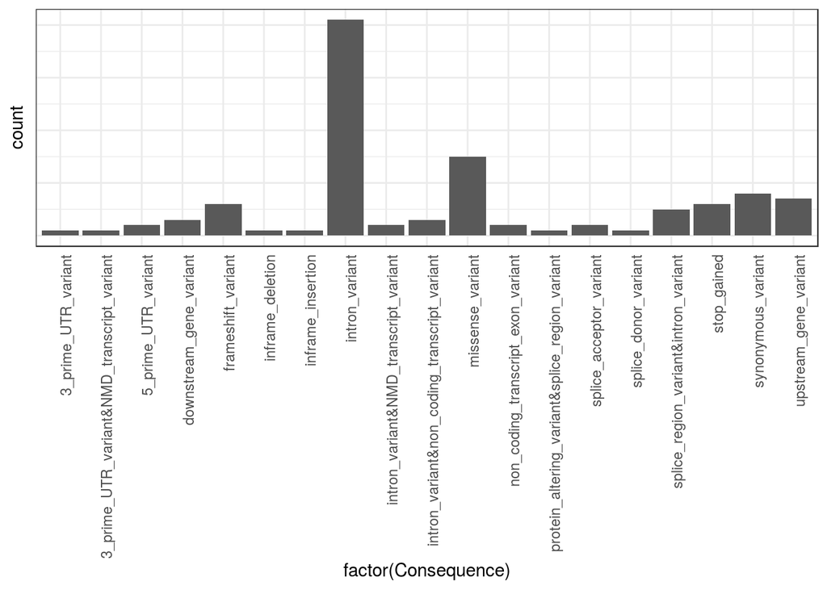

# find variants that are shared between strelka tumor and matched cell line

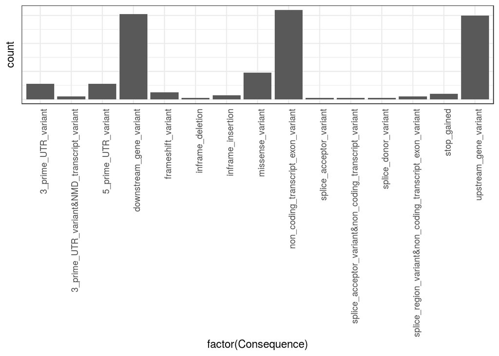

# find intersection between strelka t/cl variants + reynolds variants and variants found in other studies – Zhang

# find intersection between genes Cobrinik Zhang –strelka

# find intersection between strelka t/cl variants and variants found in other studies – Kooi

# find intersection between genes Cobrinik Kooi –strelka

# find intersection between strelkat/cl variants and variants found in other studies – McEvoy

# find intersection between genes Cobrinik McEvoy –strelka

# compile list of nonrecurrent variants from all three prior studies (Kooi, Zhang, McEvoy)

# compare three authors with strelka variants

# find intersection between mutect2 t/cl variants + reynolds variants and variants found in other studies – Zhang

# find intersection between genes Cobrinik Zhang –mutect2

# find intersection between mutect2 t/cl variants and variants found in other studies – Kooi

# find intersection between genes Cobrinik Kooi –mutect2

# find intersection between mutect2t/cl variants and variants found in other studies – McEvoy

# find intersection between genes Cobrinik McEvoy –mutect2

# compile list of nonrecurrent variants from all three prior studies (Kooi, Zhang, McEvoy)

# compare three authors with mutect2 variants

# compare mutect2 with strelka calls ————————————–

#check for overlap between stchlk SCNAs and Kooi SCNA peak regions

# find overlapping segments in SCNA

# play with somatic signatures

# plot VAF distribution